# Spotify Data Analysis

## Fall 2024 Data Science Project

Tisha Patel (UID 118676746)  
Krushi Shah (UID 118505107)  
Vikasni Senthil (UID 118969626)  
Sharvari Tirodkar (UID 118583242)  
Shreya Gavarapattu (UID 118892313)  
Shruti Marichetty (UID 118773391)

Github:  
**Link to Github Repository:** https://github.com/tpatel1221/CMSC320Final

# Contributions

A: Project idea

B: Dataset Curation and Preprocessing

C: Data Exploration and Summary Statistics

D: ML Algorithm Design/Development

E: ML Algorithm Training and Test Data Analysis

F: Visualization, Result Analysis, Conclusion

G: Final Tutorial Report Creation

H: Additional

## Group Member's Contributions

**Tisha Patel** - I contributed to the ML Algorithm Design and Development, Part D, in order to create the base of the algorithm before optimization. I also contributed to the Project Idea, part A, by helping to find the dataset and identifying interesting questions to research within the dataset

**Vikasni Senthil** - I contributed to the insights and conclusion, expanding on the result and coming up with recommended actions based on the analysis (part F). I helped connect the findings to broader trends, highlighting how the insights could be applied to real-world scenarios.

**Sharvari Tirodkar** - I contributed to creating parts of the data visualization and drawing conclusions in the exploratory data analysis (part C). I also contributed to training and testing the data with an ML model, and analyzing the outcome of this model's analysis (part E).

**Shreya Gavarapattu** - I contributed towards the dataset exploration and analysis process through conducting an analysis on one of the conclusions (part C). I also worked on the final report creation through expanding the introduction and formatting each section (part G).

**Shruti Marichetty** - I contributed to the Exploratory Data Analysis (Part C) by completing one of the hypothesis tests and drawing a conclusion from the process, as well as graphing the analysis. I also contributed to the final report creation (Part G) by helping format the entire project as well as working on the introduction portion of the project.

## Introduction

In today's world, Spotify has become a platform used by many in order to not only stream the music we want, but to also recommend us music playlists curated based on our tastes. We are all especially intrigued by the data analytics implications of Spotify's year end music recap, as it allows us to reminisce on our music progression. This is one of the very minor applications of data analysis we see in our everyday lives, yet we look forward to it. We thought it would be interesting to analyze the data of Spotify tracks on a broader level and determine what factors correlate with a song being more popular, such as duration, explicitness, danceability and energy. Furthermore, we think that the applications of analyzing this dataset would be interesting because it gives us a glimpse into what Spotify recommendation algorithm does and what some changes or iterations of their algorithm may have looked like on a simple level. Spotify's recommendation algorithm essentially suggests songs to users based on the characteristics of songs that the user already is interested in and finds a pattern to curate playlists of similar song genres. The implications of this technique are vast, as it not only allows users to find new songs, but also to connect similar songs when creating different playlists for different moods.

We wanted to answer many questions by analyzing this dataset. What specific features/characteristics make a song more likely to be popular? How do attributes like energy or danceability influence the success of a song? How might the Spotify algorithm use these factors to recommend songs to users? Not only are these questions important for Spotify users to understand the answers to, but they are also integral for anyone interested in data science to learn about as this is a practical real-world application of how data science is used to further a platform's engagement.

# Data Curation

**Dataset Chosen:** Spotify Tracks Dataset  
**Dataset Citation:** Maharshi Pandya. (2022). 🎹 Spotify Tracks Dataset [Data set]. Kaggle. https://doi.org/10.34740/KAGGLE/DSV/4372070

Introduction

Data Curation

Preprocessing

Exploratory Data Analysis

> Conclusion 1

> Conclusion 2

> Conclusion 3

ML Algorithm Primary Analysis

> Random Forest

Visualizations

Insights and Conclusion

> Conclusion

# Preprocessing

Here, we are collecting all the relevant data that we need and importing the necessary libraries that we use for analyzing this data in this study.

First, we import the necessary libraries

```python
import pandas as pd
import matplotlib.pyplot as plt
import seaborn as sns
import numpy as np
from scipy import stats
```

```python
df = pd.read_csv('dataset.csv')
df
```

|  | Unnamed: 0 | track_id | artists | album_name | track_name | popularity | duration_ms | explicit | danceability | energy | ... | loudness | mode | speechiness | acousticness | instrumentalness | liveness | valence | tempo | time_signature | track_genre |
| --- | --- | --- | --- | --- | --- | --- | --- | --- | --- | --- | --- | --- | --- | --- | --- | --- | --- | --- | --- | --- | --- |
| 0 | 0 | 5SuOikwiRyPMVoIQDJUgSV | Gen Hoshino | Comedy | Comedy | 73 | 230666 | False | 0.676 | 0.4610 | ... | -6.746 | 0 | 0.1430 | 0.0322 | 0.000001 | 0.3580 | 0.7150 | 87.917 | 4 | acoustic |
| 1 | 1 | 4qPNDBW1i3p13qLCt0Ki3A | Ben Woodward | Ghost (Acoustic) | Ghost - Acoustic | 55 | 149610 | False | 0.420 | 0.1660 | ... | -17.235 | 1 | 0.0763 | 0.9240 | 0.000006 | 0.1010 | 0.2670 | 77.489 | 4 | acoustic |
| 2 | 2 | 1iJBSr7s7jYXzM8EGcbK5b | Ingrid Michaelson;ZAYN | To Begin Again | To Begin Again | 57 | 210826 | False | 0.438 | 0.3590 | ... | -9.734 | 1 | 0.0557 | 0.2100 | 0.000000 | 0.1170 | 0.1200 | 76.332 | 4 | acoustic |
| 3 | 3 | 6lfxq3CG4xtTiEg7opyCyx | Kina Grannis | Crazy Rich Asians (Original Motion Picture Sou... | Can't Help Falling In Love | 71 | 201933 | False | 0.266 | 0.0596 | ... | -18.515 | 1 | 0.0363 | 0.9050 | 0.000071 | 0.1320 | 0.1430 | 181.740 | 3 | acoustic |
| 4 | 4 | 5vjLSffimiIP26QG5WcN2K | Chord Overstreet | Hold On | Hold On | 82 | 198853 | False | 0.618 | 0.4430 | ... | -9.681 | 1 | 0.0526 | 0.4690 | 0.000000 | 0.0829 | 0.1670 | 119.949 | 4 | acoustic |
| ... | ... | ... | ... | ... | ... | ... | ... | ... | ... | ... | ... | ... | ... | ... | ... | ... | ... | ... | ... | ... | ... |
| 113995 | 113995 | 2C3TZjDRiAzdyViavDJ217 | Rainy Lullaby | #mindfulness - Soft Rain for Mindful Meditatio... | Sleep My Little Boy | 21 | 384999 | False | 0.172 | 0.2350 | ... | -16.393 | 1 | 0.0422 | 0.6400 | 0.928000 | 0.0863 | 0.0339 | 125.995 | 5 | world-music |
| 113996 | 113996 | 1hIz5L4IB9hN3WRYPOCGPw | Rainy Lullaby | #mindfulness - Soft Rain for Mindful Meditatio... | Water Into Light | 22 | 385000 | False | 0.174 | 0.1170 | ... | -18.318 | 0 | 0.0401 | 0.9940 | 0.976000 | 0.1050 | 0.0350 | 85.239 | 4 | world-music |
| 113997 | 113997 | 6x8ZfSoqDjuNa5SVP5QjvX | Cesária Evora | Best Of | Miss Perfumado | 22 | 271466 | False | 0.629 | 0.3290 | ... | -10.895 | 0 | 0.0420 | 0.8670 | 0.000000 | 0.0839 | 0.7430 | 132.378 | 4 | world-music |
| 113998 | 113998 | 2e6sXL2bYv4bSz6VTdnfLs | Michael W. Smith | Change Your World | Friends | 41 | 283893 | False | 0.587 | 0.5060 | ... | -10.889 | 1 | 0.0297 | 0.3810 | 0.000000 | 0.2700 | 0.4130 | 135.960 | 4 | world-music |
| 113999 | 113999 | 2hETkH7cOfqmz3LqZDHZf5 | Cesária Evora | Miss Perfumado | Barbincor | 22 | 241826 | False | 0.526 | 0.4870 | ... | -10.204 | 0 | 0.0725 | 0.6810 | 0.000000 | 0.0893 | 0.7080 | 79.198 | 4 | world-music |

114000 rows × 21 columns

Next, we determine which data type each thing is and parse the strings to ints.

```python
df.dtypes
```

|  | 0 |
| --- | --- |
| Unnamed: 0 | int64 |
| track_id | object |
| artists | object |
| album_name | object |
| track_name | object |
| popularity | int64 |
| duration_ms | int64 |
| explicit | bool |
| danceability | float64 |
| energy | float64 |
| key | int64 |
| loudness | float64 |
| mode | int64 |
| speechiness | float64 |
| acousticness | float64 |
| instrumentalness | float64 |
| liveness | float64 |
| valence | float64 |
| tempo | float64 |
| time_signature | int64 |
| track_genre | object |

**dtype:** object

There is nothing to parse as show above, there are not strings. Next, we organize the info. We have already set up a pandas DataFrame. We are ready to explore our data!

# Exploratory Data Analysis

Here, we want to gain a better understanding of the data based on the trends we discover.

We develop our conclusions and hypotheses for our dataset and test them initially. Typically, a range is created in order to assess data in a ranking format. Once the dataframe is split accordingly to the range, a test is conducted and the results are analyzed through a graph and conclusion that is displayed.

This section, as a whole, allows us to determine the patterns and relationships between certain variables, and gain a visual representation of this relationship.

### Conclusion 1

First, we will explore the relationship between the danceability of the track and its popularity.  
**We will assume $\alpha = 0.05$.**

#### Hypothesis 1

- HO: The danceability of the track has no effect on the popularity of the track
- HA: The danaceability of the track has an effect on the popularity of the track

### Hypothesis Testing

We will first split the dataframe based on the songs' captured danceability rating.

```python
minDance = min(df['danceability'])
maxDance = max(df['danceability'])

print(f"The minimum value in danceability is {minDance} and the maximum value in danceability is {maxDance}")
```

```
The minimum value in danceability is 0.0 and the maximum value in danceability is 0.985
```

Based on this range, we will add a column called danceability_rank that ranks the danceability.

- Low Danceability: 0.00 - 0.35
- Medium Danceability: 0.36 - 0.70
- High Danceability: 0.71 - 0.99

```python
def danceability_ranker(danceability):
    if 0.00 <= danceability <= 0.35:
        return 'Low'
    elif 0.36 <= danceability <= 0.70:
        return 'Medium'
    elif 0.71 <= danceability <= 0.99:
        return 'High'

df['danceability_rank'] = df['danceability'].apply(danceability_ranker)
df
```

|  | Unnamed: 0 | track_id | artists | album_name | track_name | popularity | duration_ms | explicit | danceability | energy | ... | mode | speechiness | acousticness | instrumentalness | liveness | valence | tempo | time_signature | track_genre | danceability_rank |
| --- | --- | --- | --- | --- | --- | --- | --- | --- | --- | --- | --- | --- | --- | --- | --- | --- | --- | --- | --- | --- | --- |
| 0 | 0 | 5SuOikwiRyPMVoIQDJUgSV | Gen Hoshino | Comedy | Comedy | 73 | 230666 | False | 0.676 | 0.4610 | ... | 0 | 0.1430 | 0.0322 | 0.000001 | 0.3580 | 0.7150 | 87.917 | 4 | acoustic | Medium |
| 1 | 1 | 4qPNDBW1i3p13qLCt0Ki3A | Ben Woodward | Ghost (Acoustic) | Ghost - Acoustic | 55 | 149610 | False | 0.420 | 0.1660 | ... | 1 | 0.0763 | 0.9240 | 0.000006 | 0.1010 | 0.2670 | 77.489 | 4 | acoustic | Medium |
| 2 | 2 | 1iJBSr7s7jYXzM8EGcbK5b | Ingrid Michaelson;ZAYN | To Begin Again | To Begin Again | 57 | 210826 | False | 0.438 | 0.3590 | ... | 1 | 0.0557 | 0.2100 | 0.000000 | 0.1170 | 0.1200 | 76.332 | 4 | acoustic | Medium |
| 3 | 3 | 6lfxq3CG4xtTiEg7opyCyx | Kina Grannis | Crazy Rich Asians (Original Motion Picture Sou... | Can't Help Falling In Love | 71 | 201933 | False | 0.266 | 0.0596 | ... | 1 | 0.0363 | 0.9050 | 0.000071 | 0.1320 | 0.1430 | 181.740 | 3 | acoustic | Low |
| 4 | 4 | 5vjLSffimiIP26QG5WcN2K | Chord Overstreet | Hold On | Hold On | 82 | 198853 | False | 0.618 | 0.4430 | ... | 1 | 0.0526 | 0.4690 | 0.000000 | 0.0829 | 0.1670 | 119.949 | 4 | acoustic | Medium |
| ... | ... | ... | ... | ... | ... | ... | ... | ... | ... | ... | ... | ... | ... | ... | ... | ... | ... | ... | ... | ... | ... |
| 113995 | 113995 | 2C3TZjDRiAzdyViavDJ217 | Rainy Lullaby | #mindfulness - Soft Rain for Mindful Meditatio... | Sleep My Little Boy | 21 | 384999 | False | 0.172 | 0.2350 | ... | 1 | 0.0422 | 0.6400 | 0.928000 | 0.0863 | 0.0339 | 125.995 | 5 | world-music | Low |
| 113996 | 113996 | 1hIz5L4IB9hN3WRYPOCGPw | Rainy Lullaby | #mindfulness - Soft Rain for Mindful Meditatio... | Water Into Light | 22 | 385000 | False | 0.174 | 0.1170 | ... | 0 | 0.0401 | 0.9940 | 0.976000 | 0.1050 | 0.0350 | 85.239 | 4 | world-music | Low |
| 113997 | 113997 | 6x8ZfSoqDjuNa5SVP5QjvX | Cesária Evora | Best Of | Miss Perfumado | 22 | 271466 | False | 0.629 | 0.3290 | ... | 0 | 0.0420 | 0.8670 | 0.000000 | 0.0839 | 0.7430 | 132.378 | 4 | world-music | Medium |
| 113998 | 113998 | 2e6sXL2bYv4bSz6VTdnfLs | Michael W. Smith | Change Your World | Friends | 41 | 283893 | False | 0.587 | 0.5060 | ... | 1 | 0.0297 | 0.3810 | 0.000000 | 0.2700 | 0.4130 | 135.960 | 4 | world-music | Medium |
| 113999 | 113999 | 2hETkH7cOfqmz3LqZDHZf5 | Cesária Evora | Miss Perfumado | Barbincor | 22 | 241826 | False | 0.526 | 0.4870 | ... | 0 | 0.0725 | 0.6810 | 0.000000 | 0.0893 | 0.7080 | 79.198 | 4 | world-music | Medium |

114000 rows × 22 columns

Now, we will split the dataframe based on the danceability ranking.

```python
groups = df.groupby(df['danceability_rank'])

for (name, group) in groups:
  print(f"Ranking: {name} \n {group}")
```

[output not shown]

[output cut: 212 more lines]

Now, we will conduct the test.

```python
from scipy.stats import f_oneway

val = []
for (category, data) in groups:
  val.append(data['popularity'].values)

a, pval = f_oneway(*val)

pval
```

```
6.2782022111233374e-164
```

#### Conclusion

Because the p-value is less than 0.05, we reject the null hypothesis. We can conclude that our observed results are unlikely to occur under the hypothesis is that the danceability of the track has no effect on the popularity of the track. Post-hoc tests will need to be conducted because we rejected the null hypothesis, in order to identify which of the three levels of danceability is significantly different.

#### Graph for Conclusion 1

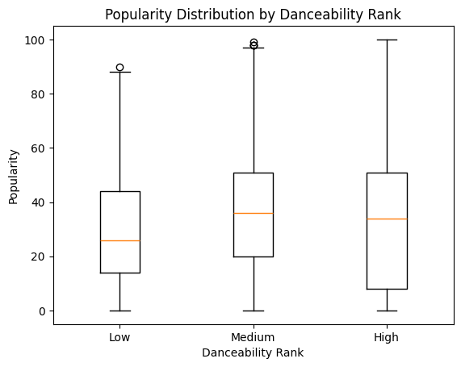

```python
plt.boxplot([df[df['danceability_rank'] == 'Low']['popularity'],
             df[df['danceability_rank'] == 'Medium']['popularity'],
             df[df['danceability_rank'] == 'High']['popularity']],
            labels = ['Low', 'Medium', 'High'])

plt.title("Popularity Distribution by Danceability Rank")
plt.xlabel("Danceability Rank")
plt.ylabel("Popularity")

plt.show()
```

```python
from statsmodels.stats.multicomp import pairwise_tukeyhsd

df = df.dropna(subset=['danceability_rank'])

tukey_results = pairwise_tukeyhsd(endog=df['popularity'], groups=df['danceability_rank'], alpha=0.05)

results_df = pd.DataFrame(data=tukey_results._results_table.data[1:], columns=tukey_results._results_table.data[0])
comparison_p_values = results_df[['group1', 'group2', 'meandiff', 'p-adj']]
print(comparison_p_values)
```

```
  group1  group2  meandiff  p-adj
0   High     Low   -3.6817    0.0
1   High  Medium    1.8852    0.0
2    Low  Medium    5.5669    0.0
```

Now, we will drop the danceability rank column as to not interfere with the rest of our data.

```python
df.drop('danceability_rank', axis = 1)
```

|  | Unnamed: 0 | track_id | artists | album_name | track_name | popularity | duration_ms | explicit | danceability | energy | ... | loudness | mode | speechiness | acousticness | instrumentalness | liveness | valence | tempo | time_signature | track_genre |
| --- | --- | --- | --- | --- | --- | --- | --- | --- | --- | --- | --- | --- | --- | --- | --- | --- | --- | --- | --- | --- | --- |
| 0 | 0 | 5SuOikwiRyPMVoIQDJUgSV | Gen Hoshino | Comedy | Comedy | 73 | 230666 | False | 0.676 | 0.4610 | ... | -6.746 | 0 | 0.1430 | 0.0322 | 0.000001 | 0.3580 | 0.7150 | 87.917 | 4 | acoustic |
| 1 | 1 | 4qPNDBW1i3p13qLCt0Ki3A | Ben Woodward | Ghost (Acoustic) | Ghost - Acoustic | 55 | 149610 | False | 0.420 | 0.1660 | ... | -17.235 | 1 | 0.0763 | 0.9240 | 0.000006 | 0.1010 | 0.2670 | 77.489 | 4 | acoustic |
| 2 | 2 | 1iJBSr7s7jYXzM8EGcbK5b | Ingrid Michaelson;ZAYN | To Begin Again | To Begin Again | 57 | 210826 | False | 0.438 | 0.3590 | ... | -9.734 | 1 | 0.0557 | 0.2100 | 0.000000 | 0.1170 | 0.1200 | 76.332 | 4 | acoustic |
| 3 | 3 | 6lfxq3CG4xtTiEg7opyCyx | Kina Grannis | Crazy Rich Asians (Original Motion Picture Sou... | Can't Help Falling In Love | 71 | 201933 | False | 0.266 | 0.0596 | ... | -18.515 | 1 | 0.0363 | 0.9050 | 0.000071 | 0.1320 | 0.1430 | 181.740 | 3 | acoustic |
| 4 | 4 | 5vjLSffimiIP26QG5WcN2K | Chord Overstreet | Hold On | Hold On | 82 | 198853 | False | 0.618 | 0.4430 | ... | -9.681 | 1 | 0.0526 | 0.4690 | 0.000000 | 0.0829 | 0.1670 | 119.949 | 4 | acoustic |
| ... | ... | ... | ... | ... | ... | ... | ... | ... | ... | ... | ... | ... | ... | ... | ... | ... | ... | ... | ... | ... | ... |
| 113995 | 113995 | 2C3TZjDRiAzdyViavDJ217 | Rainy Lullaby | #mindfulness - Soft Rain for Mindful Meditatio... | Sleep My Little Boy | 21 | 384999 | False | 0.172 | 0.2350 | ... | -16.393 | 1 | 0.0422 | 0.6400 | 0.928000 | 0.0863 | 0.0339 | 125.995 | 5 | world-music |
| 113996 | 113996 | 1hIz5L4IB9hN3WRYPOCGPw | Rainy Lullaby | #mindfulness - Soft Rain for Mindful Meditatio... | Water Into Light | 22 | 385000 | False | 0.174 | 0.1170 | ... | -18.318 | 0 | 0.0401 | 0.9940 | 0.976000 | 0.1050 | 0.0350 | 85.239 | 4 | world-music |
| 113997 | 113997 | 6x8ZfSoqDjuNa5SVP5QjvX | Cesária Evora | Best Of | Miss Perfumado | 22 | 271466 | False | 0.629 | 0.3290 | ... | -10.895 | 0 | 0.0420 | 0.8670 | 0.000000 | 0.0839 | 0.7430 | 132.378 | 4 | world-music |
| 113998 | 113998 | 2e6sXL2bYv4bSz6VTdnfLs | Michael W. Smith | Change Your World | Friends | 41 | 283893 | False | 0.587 | 0.5060 | ... | -10.889 | 1 | 0.0297 | 0.3810 | 0.000000 | 0.2700 | 0.4130 | 135.960 | 4 | world-music |
| 113999 | 113999 | 2hETkH7cOfqmz3LqZDHZf5 | Cesária Evora | Miss Perfumado | Barbincor | 22 | 241826 | False | 0.526 | 0.4870 | ... | -10.204 | 0 | 0.0725 | 0.6810 | 0.000000 | 0.0893 | 0.7080 | 79.198 | 4 | world-music |

110931 rows × 21 columns

### Conclusion 2

Hypothesis 2:

HO: The energy of the track has no effect on the popularity of the track.

H1: The energy of the track has an effect on the popularity of the track.

**Hypothesis Testing:**

```python
minEnergy = min(df['energy'])
maxEnergy = max(df['energy'])

print(f"The minimum value in energy is {minEnergy} and the maximum value in energy is {maxEnergy}")
```

```
The minimum value in energy is 0.0 and the maximum value in energy is 1.0
```

Based on this range, we will add a column called `energy_rank` that ranks the energy of the track.

**Low Energy:** 0.00 - 0.35

**Medium Energy:** 0.36 - 0.70

**High Energy:** 0.71 - 0.99

```python
def energy_ranker(energy):
    if 0.00 <= energy <= 0.35:
        return 'Low'
    elif 0.36 <= energy <= 0.70:
        return 'Medium'
    elif 0.71 <= energy <= 0.99:
        return 'High'

df['energy_rank'] = df['energy'].apply(energy_ranker)
df
```

|  | Unnamed: 0 | track_id | artists | album_name | track_name | popularity | duration_ms | explicit | danceability | energy | ... | speechiness | acousticness | instrumentalness | liveness | valence | tempo | time_signature | track_genre | danceability_rank | energy_rank |
| --- | --- | --- | --- | --- | --- | --- | --- | --- | --- | --- | --- | --- | --- | --- | --- | --- | --- | --- | --- | --- | --- |
| 0 | 0 | 5SuOikwiRyPMVoIQDJUgSV | Gen Hoshino | Comedy | Comedy | 73 | 230666 | False | 0.676 | 0.4610 | ... | 0.1430 | 0.0322 | 0.000001 | 0.3580 | 0.7150 | 87.917 | 4 | acoustic | Medium | Medium |
| 1 | 1 | 4qPNDBW1i3p13qLCt0Ki3A | Ben Woodward | Ghost (Acoustic) | Ghost - Acoustic | 55 | 149610 | False | 0.420 | 0.1660 | ... | 0.0763 | 0.9240 | 0.000006 | 0.1010 | 0.2670 | 77.489 | 4 | acoustic | Medium | Low |
| 2 | 2 | 1iJBSr7s7jYXzM8EGcbK5b | Ingrid Michaelson;ZAYN | To Begin Again | To Begin Again | 57 | 210826 | False | 0.438 | 0.3590 | ... | 0.0557 | 0.2100 | 0.000000 | 0.1170 | 0.1200 | 76.332 | 4 | acoustic | Medium | None |
| 3 | 3 | 6lfxq3CG4xtTiEg7opyCyx | Kina Grannis | Crazy Rich Asians (Original Motion Picture Sou... | Can't Help Falling In Love | 71 | 201933 | False | 0.266 | 0.0596 | ... | 0.0363 | 0.9050 | 0.000071 | 0.1320 | 0.1430 | 181.740 | 3 | acoustic | Low | Low |
| 4 | 4 | 5vjLSffimiIP26QG5WcN2K | Chord Overstreet | Hold On | Hold On | 82 | 198853 | False | 0.618 | 0.4430 | ... | 0.0526 | 0.4690 | 0.000000 | 0.0829 | 0.1670 | 119.949 | 4 | acoustic | Medium | Medium |
| ... | ... | ... | ... | ... | ... | ... | ... | ... | ... | ... | ... | ... | ... | ... | ... | ... | ... | ... | ... | ... | ... |
| 113995 | 113995 | 2C3TZjDRiAzdyViavDJ217 | Rainy Lullaby | #mindfulness - Soft Rain for Mindful Meditatio... | Sleep My Little Boy | 21 | 384999 | False | 0.172 | 0.2350 | ... | 0.0422 | 0.6400 | 0.928000 | 0.0863 | 0.0339 | 125.995 | 5 | world-music | Low | Low |
| 113996 | 113996 | 1hIz5L4IB9hN3WRYPOCGPw | Rainy Lullaby | #mindfulness - Soft Rain for Mindful Meditatio... | Water Into Light | 22 | 385000 | False | 0.174 | 0.1170 | ... | 0.0401 | 0.9940 | 0.976000 | 0.1050 | 0.0350 | 85.239 | 4 | world-music | Low | Low |
| 113997 | 113997 | 6x8ZfSoqDjuNa5SVP5QjvX | Cesária Evora | Best Of | Miss Perfumado | 22 | 271466 | False | 0.629 | 0.3290 | ... | 0.0420 | 0.8670 | 0.000000 | 0.0839 | 0.7430 | 132.378 | 4 | world-music | Medium | Low |
| 113998 | 113998 | 2e6sXL2bYv4bSz6VTdnfLs | Michael W. Smith | Change Your World | Friends | 41 | 283893 | False | 0.587 | 0.5060 | ... | 0.0297 | 0.3810 | 0.000000 | 0.2700 | 0.4130 | 135.960 | 4 | world-music | Medium | Medium |
| 113999 | 113999 | 2hETkH7cOfqmz3LqZDHZf5 | Cesária Evora | Miss Perfumado | Barbincor | 22 | 241826 | False | 0.526 | 0.4870 | ... | 0.0725 | 0.6810 | 0.000000 | 0.0893 | 0.7080 | 79.198 | 4 | world-music | Medium | Medium |

110931 rows × 23 columns

Now, split the dataframe based on the energy ranking.

```python
groups = df.groupby(df['energy_rank'])

for (name, group) in groups:
  print(f"Ranking: {name} \n {group}")
```

[output not shown]

[output cut: 225 more lines]

We will also categorize the popularity into "Low", "Medium", and "High" categories.

```python
def popularity_ranker(popularity):
    if 0 <= popularity <= 30:
        return 'Low'
    elif 31 <= popularity <= 60:
        return 'Medium'
    elif 61 <= popularity <= 100:
        return 'High'

df['popularity_rank'] = df['popularity'].apply(popularity_ranker)
df
```

|  | Unnamed: 0 | track_id | artists | album_name | track_name | popularity | duration_ms | explicit | danceability | energy | ... | acousticness | instrumentalness | liveness | valence | tempo | time_signature | track_genre | danceability_rank | energy_rank | popularity_rank |
| --- | --- | --- | --- | --- | --- | --- | --- | --- | --- | --- | --- | --- | --- | --- | --- | --- | --- | --- | --- | --- | --- |
| 0 | 0 | 5SuOikwiRyPMVoIQDJUgSV | Gen Hoshino | Comedy | Comedy | 73 | 230666 | False | 0.676 | 0.4610 | ... | 0.0322 | 0.000001 | 0.3580 | 0.7150 | 87.917 | 4 | acoustic | Medium | Medium | High |
| 1 | 1 | 4qPNDBW1i3p13qLCt0Ki3A | Ben Woodward | Ghost (Acoustic) | Ghost - Acoustic | 55 | 149610 | False | 0.420 | 0.1660 | ... | 0.9240 | 0.000006 | 0.1010 | 0.2670 | 77.489 | 4 | acoustic | Medium | Low | Medium |
| 2 | 2 | 1iJBSr7s7jYXzM8EGcbK5b | Ingrid Michaelson;ZAYN | To Begin Again | To Begin Again | 57 | 210826 | False | 0.438 | 0.3590 | ... | 0.2100 | 0.000000 | 0.1170 | 0.1200 | 76.332 | 4 | acoustic | Medium | None | Medium |
| 3 | 3 | 6lfxq3CG4xtTiEg7opyCyx | Kina Grannis | Crazy Rich Asians (Original Motion Picture Sou... | Can't Help Falling In Love | 71 | 201933 | False | 0.266 | 0.0596 | ... | 0.9050 | 0.000071 | 0.1320 | 0.1430 | 181.740 | 3 | acoustic | Low | Low | High |
| 4 | 4 | 5vjLSffimiIP26QG5WcN2K | Chord Overstreet | Hold On | Hold On | 82 | 198853 | False | 0.618 | 0.4430 | ... | 0.4690 | 0.000000 | 0.0829 | 0.1670 | 119.949 | 4 | acoustic | Medium | Medium | High |
| ... | ... | ... | ... | ... | ... | ... | ... | ... | ... | ... | ... | ... | ... | ... | ... | ... | ... | ... | ... | ... | ... |
| 113995 | 113995 | 2C3TZjDRiAzdyViavDJ217 | Rainy Lullaby | #mindfulness - Soft Rain for Mindful Meditatio... | Sleep My Little Boy | 21 | 384999 | False | 0.172 | 0.2350 | ... | 0.6400 | 0.928000 | 0.0863 | 0.0339 | 125.995 | 5 | world-music | Low | Low | Low |
| 113996 | 113996 | 1hIz5L4IB9hN3WRYPOCGPw | Rainy Lullaby | #mindfulness - Soft Rain for Mindful Meditatio... | Water Into Light | 22 | 385000 | False | 0.174 | 0.1170 | ... | 0.9940 | 0.976000 | 0.1050 | 0.0350 | 85.239 | 4 | world-music | Low | Low | Low |
| 113997 | 113997 | 6x8ZfSoqDjuNa5SVP5QjvX | Cesária Evora | Best Of | Miss Perfumado | 22 | 271466 | False | 0.629 | 0.3290 | ... | 0.8670 | 0.000000 | 0.0839 | 0.7430 | 132.378 | 4 | world-music | Medium | Low | Low |
| 113998 | 113998 | 2e6sXL2bYv4bSz6VTdnfLs | Michael W. Smith | Change Your World | Friends | 41 | 283893 | False | 0.587 | 0.5060 | ... | 0.3810 | 0.000000 | 0.2700 | 0.4130 | 135.960 | 4 | world-music | Medium | Medium | Medium |
| 113999 | 113999 | 2hETkH7cOfqmz3LqZDHZf5 | Cesária Evora | Miss Perfumado | Barbincor | 22 | 241826 | False | 0.526 | 0.4870 | ... | 0.6810 | 0.000000 | 0.0893 | 0.7080 | 79.198 | 4 | world-music | Medium | Medium | Low |

110931 rows × 24 columns

Now split it based on the energy and popularity. Following this, create a contingency table to summarize the counts of each combination of energy and popularity.

```python
df['energy_rank'] = df['energy'].apply(energy_ranker)
contingency_table = pd.crosstab(df['energy_rank'], df['popularity_rank'])
print(contingency_table)
```

```
popularity_rank  High    Low  Medium
energy_rank
High             5947  23655   20400
Low              1368   8810    6730
Medium           5571  16089   18791
```

Now, we conduct the test. We will use Chi-Square Test.

```python
from scipy.stats import chi2_contingency

chi2, pval_chi2, dof, expected = chi2_contingency(contingency_table)

pval_chi2
```

```
1.0612995561711994e-219
```

Based on the number above, the value is way below the significance level of 0.05. This indicates a significant relationship between the energy of a track and its popularity, leading us to reject the null hypothesis.

Now we will make a graph for Conclusion 2.

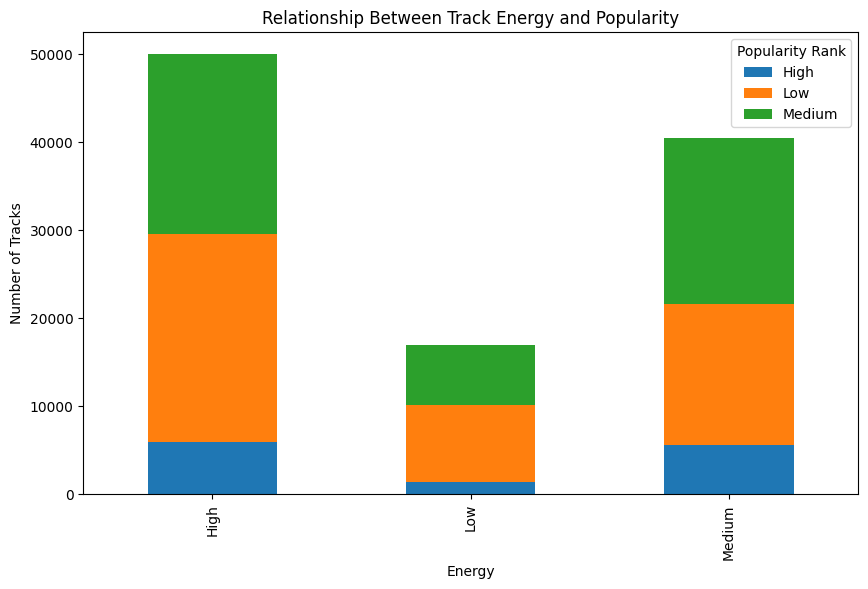

```python
import matplotlib.pyplot as plt

contingency_table.plot(kind='bar', stacked=True, figsize=(10, 6))

plt.title('Relationship Between Track Energy and Popularity')
plt.xlabel('Energy')
plt.ylabel('Number of Tracks')
plt.legend(title='Popularity Rank')

plt.show()
```

Finally, we will drop the `popularity_rank` and `energy_rank` columns to avoid interference with the rest of our analysis.

```python
df.drop(['popularity_rank', 'energy_rank'], axis=1, inplace=True)
```

### Conclusion 3

Finally, we will explore the relationship between the acousticness of the track and its popularity.  
**We will assume $\alpha = 0.05$.**

Hypothesis 3:

H0: The acousticness of a track has no effect on its popularity.

HA: The acousticness of a track has an effect on its popularity.

**Hypothesis Testing:**

```python
minAcoustic = min(df['acousticness'])
maxAcoustic = max(df['acousticness'])

print(f"The minimum value in acousticness is {minAcoustic} and the maximum value in acousticness is {maxAcoustic}")
```

```
The minimum value in acousticness is 0.0 and the maximum value in acousticness is 0.996
```

Based on this range, we will add a column called `acoustic_rank` that ranks the acousticness of the track.

**Low Acousticness:** 0.00 - 0.498

**High Acousticness:** 0.498 - 0.996

```python
def acoustic_ranker(acousticness):
    if 0.00 <= acousticness <= 0.498:
        return 'Low'
    elif 0.498 <= acousticness <= 0.996:
        return 'High'

df['acoustic_rank'] = df['acousticness'].apply(acoustic_ranker)
df
```

|  | Unnamed: 0 | track_id | artists | album_name | track_name | popularity | duration_ms | explicit | danceability | energy | ... | speechiness | acousticness | instrumentalness | liveness | valence | tempo | time_signature | track_genre | danceability_rank | acoustic_rank |
| --- | --- | --- | --- | --- | --- | --- | --- | --- | --- | --- | --- | --- | --- | --- | --- | --- | --- | --- | --- | --- | --- |
| 0 | 0 | 5SuOikwiRyPMVoIQDJUgSV | Gen Hoshino | Comedy | Comedy | 73 | 230666 | False | 0.676 | 0.4610 | ... | 0.1430 | 0.0322 | 0.000001 | 0.3580 | 0.7150 | 87.917 | 4 | acoustic | Medium | Low |
| 1 | 1 | 4qPNDBW1i3p13qLCt0Ki3A | Ben Woodward | Ghost (Acoustic) | Ghost - Acoustic | 55 | 149610 | False | 0.420 | 0.1660 | ... | 0.0763 | 0.9240 | 0.000006 | 0.1010 | 0.2670 | 77.489 | 4 | acoustic | Medium | High |
| 2 | 2 | 1iJBSr7s7jYXzM8EGcbK5b | Ingrid Michaelson;ZAYN | To Begin Again | To Begin Again | 57 | 210826 | False | 0.438 | 0.3590 | ... | 0.0557 | 0.2100 | 0.000000 | 0.1170 | 0.1200 | 76.332 | 4 | acoustic | Medium | Low |
| 3 | 3 | 6lfxq3CG4xtTiEg7opyCyx | Kina Grannis | Crazy Rich Asians (Original Motion Picture Sou... | Can't Help Falling In Love | 71 | 201933 | False | 0.266 | 0.0596 | ... | 0.0363 | 0.9050 | 0.000071 | 0.1320 | 0.1430 | 181.740 | 3 | acoustic | Low | High |
| 4 | 4 | 5vjLSffimiIP26QG5WcN2K | Chord Overstreet | Hold On | Hold On | 82 | 198853 | False | 0.618 | 0.4430 | ... | 0.0526 | 0.4690 | 0.000000 | 0.0829 | 0.1670 | 119.949 | 4 | acoustic | Medium | Low |
| ... | ... | ... | ... | ... | ... | ... | ... | ... | ... | ... | ... | ... | ... | ... | ... | ... | ... | ... | ... | ... | ... |
| 113995 | 113995 | 2C3TZjDRiAzdyViavDJ217 | Rainy Lullaby | #mindfulness - Soft Rain for Mindful Meditatio... | Sleep My Little Boy | 21 | 384999 | False | 0.172 | 0.2350 | ... | 0.0422 | 0.6400 | 0.928000 | 0.0863 | 0.0339 | 125.995 | 5 | world-music | Low | High |
| 113996 | 113996 | 1hIz5L4IB9hN3WRYPOCGPw | Rainy Lullaby | #mindfulness - Soft Rain for Mindful Meditatio... | Water Into Light | 22 | 385000 | False | 0.174 | 0.1170 | ... | 0.0401 | 0.9940 | 0.976000 | 0.1050 | 0.0350 | 85.239 | 4 | world-music | Low | High |
| 113997 | 113997 | 6x8ZfSoqDjuNa5SVP5QjvX | Cesária Evora | Best Of | Miss Perfumado | 22 | 271466 | False | 0.629 | 0.3290 | ... | 0.0420 | 0.8670 | 0.000000 | 0.0839 | 0.7430 | 132.378 | 4 | world-music | Medium | High |
| 113998 | 113998 | 2e6sXL2bYv4bSz6VTdnfLs | Michael W. Smith | Change Your World | Friends | 41 | 283893 | False | 0.587 | 0.5060 | ... | 0.0297 | 0.3810 | 0.000000 | 0.2700 | 0.4130 | 135.960 | 4 | world-music | Medium | Low |
| 113999 | 113999 | 2hETkH7cOfqmz3LqZDHZf5 | Cesária Evora | Miss Perfumado | Barbincor | 22 | 241826 | False | 0.526 | 0.4870 | ... | 0.0725 | 0.6810 | 0.000000 | 0.0893 | 0.7080 | 79.198 | 4 | world-music | Medium | High |

110931 rows × 23 columns

Now, we will split the dataframe based on the acoustic ranking.

```python
groups = df.groupby(df['acoustic_rank'])

for (name, group) in groups:
  print(f"Ranking: {name} \n {group}")
```

[output not shown]

[output cut: 145 more lines]

Now, we will conduct the test.

```python
from scipy import stats
from statsmodels.stats.weightstats import ztest

low_acousticness = df[df['acousticness'] <= 0.498]['popularity']
high_acousticness = df[df['acousticness'] > 0.498]['popularity']

z_score_acousticness, pval_ztest_acousticness = ztest(low_acousticness, high_acousticness)

print(f"Z-Score: {z_score_acousticness}")
print(f"P-value: {pval_ztest_acousticness}")
```

```
Z-Score: 10.40607586819856
P-value: 2.3261346554203155e-25
```

#### Conclusion

Because the p-value is less than 0.05, we reject the null hypothesis. This means that the difference in popularity between tracks of different levels of acousticness is statistically significant. Therefore, acousticness does have a significant effect on the popularity of a track.

#### Graph for Conclusion 3

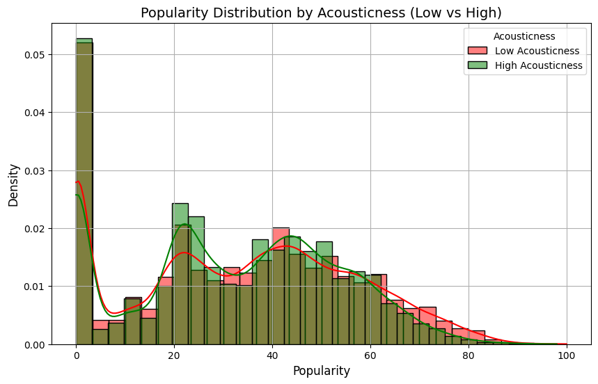

```python
plt.figure(figsize=(10,6))

sns.histplot(low_acousticness, kde=True, label="Low Acousticness", color='red', stat='density', bins=30)

sns.histplot(high_acousticness, kde=True, label="High Acousticness", color='green', stat='density', bins=30)

plt.title("Popularity Distribution by Acousticness (Low vs High)", fontsize=14)
plt.xlabel("Popularity", fontsize=12)
plt.ylabel("Density", fontsize=12)
plt.legend(title="Acousticness")
plt.grid(True)
plt.show()
```

Now, we will drop the acoustic rank column as to not interfere with the rest of our data.

```python
df.drop('acoustic_rank', axis = 1)
```

|  | Unnamed: 0 | track_id | artists | album_name | track_name | popularity | duration_ms | explicit | danceability | energy | ... | mode | speechiness | acousticness | instrumentalness | liveness | valence | tempo | time_signature | track_genre | danceability_rank |
| --- | --- | --- | --- | --- | --- | --- | --- | --- | --- | --- | --- | --- | --- | --- | --- | --- | --- | --- | --- | --- | --- |
| 0 | 0 | 5SuOikwiRyPMVoIQDJUgSV | Gen Hoshino | Comedy | Comedy | 73 | 230666 | False | 0.676 | 0.4610 | ... | 0 | 0.1430 | 0.0322 | 0.000001 | 0.3580 | 0.7150 | 87.917 | 4 | acoustic | Medium |
| 1 | 1 | 4qPNDBW1i3p13qLCt0Ki3A | Ben Woodward | Ghost (Acoustic) | Ghost - Acoustic | 55 | 149610 | False | 0.420 | 0.1660 | ... | 1 | 0.0763 | 0.9240 | 0.000006 | 0.1010 | 0.2670 | 77.489 | 4 | acoustic | Medium |
| 2 | 2 | 1iJBSr7s7jYXzM8EGcbK5b | Ingrid Michaelson;ZAYN | To Begin Again | To Begin Again | 57 | 210826 | False | 0.438 | 0.3590 | ... | 1 | 0.0557 | 0.2100 | 0.000000 | 0.1170 | 0.1200 | 76.332 | 4 | acoustic | Medium |
| 3 | 3 | 6lfxq3CG4xtTiEg7opyCyx | Kina Grannis | Crazy Rich Asians (Original Motion Picture Sou... | Can't Help Falling In Love | 71 | 201933 | False | 0.266 | 0.0596 | ... | 1 | 0.0363 | 0.9050 | 0.000071 | 0.1320 | 0.1430 | 181.740 | 3 | acoustic | Low |
| 4 | 4 | 5vjLSffimiIP26QG5WcN2K | Chord Overstreet | Hold On | Hold On | 82 | 198853 | False | 0.618 | 0.4430 | ... | 1 | 0.0526 | 0.4690 | 0.000000 | 0.0829 | 0.1670 | 119.949 | 4 | acoustic | Medium |
| ... | ... | ... | ... | ... | ... | ... | ... | ... | ... | ... | ... | ... | ... | ... | ... | ... | ... | ... | ... | ... | ... |
| 113995 | 113995 | 2C3TZjDRiAzdyViavDJ217 | Rainy Lullaby | #mindfulness - Soft Rain for Mindful Meditatio... | Sleep My Little Boy | 21 | 384999 | False | 0.172 | 0.2350 | ... | 1 | 0.0422 | 0.6400 | 0.928000 | 0.0863 | 0.0339 | 125.995 | 5 | world-music | Low |
| 113996 | 113996 | 1hIz5L4IB9hN3WRYPOCGPw | Rainy Lullaby | #mindfulness - Soft Rain for Mindful Meditatio... | Water Into Light | 22 | 385000 | False | 0.174 | 0.1170 | ... | 0 | 0.0401 | 0.9940 | 0.976000 | 0.1050 | 0.0350 | 85.239 | 4 | world-music | Low |
| 113997 | 113997 | 6x8ZfSoqDjuNa5SVP5QjvX | Cesária Evora | Best Of | Miss Perfumado | 22 | 271466 | False | 0.629 | 0.3290 | ... | 0 | 0.0420 | 0.8670 | 0.000000 | 0.0839 | 0.7430 | 132.378 | 4 | world-music | Medium |
| 113998 | 113998 | 2e6sXL2bYv4bSz6VTdnfLs | Michael W. Smith | Change Your World | Friends | 41 | 283893 | False | 0.587 | 0.5060 | ... | 1 | 0.0297 | 0.3810 | 0.000000 | 0.2700 | 0.4130 | 135.960 | 4 | world-music | Medium |
| 113999 | 113999 | 2hETkH7cOfqmz3LqZDHZf5 | Cesária Evora | Miss Perfumado | Barbincor | 22 | 241826 | False | 0.526 | 0.4870 | ... | 0 | 0.0725 | 0.6810 | 0.000000 | 0.0893 | 0.7080 | 79.198 | 4 | world-music | Medium |

110931 rows × 22 columns

# ML Algorithm Primary Analysis

In the Machine Learning stage of our analysis, we are able to obtain a predictive model for our data based on the modeling technique of our choice. This allows us to predict the Spotify trends in future years, based on the trends we analyzed with our current dataset. In this analysis, we utilize the random forest regressor as our technique in order to obtain our predictive model.

Now we will apply a machine learning technique to predict the popularity of a certain track based on certain features.

## Random Forest

We will be using the Random Forest regressor.

We begin by importing all necessary libraries, including the sci-kit learn modules necessary to utilize Random Forest.

```python
import pandas as pd
from sklearn.model_selection import train_test_split
from sklearn.ensemble import RandomForestRegressor
from sklearn.metrics import mean_squared_error, r2_score
from sklearn.preprocessing import StandardScaler
```

Because it is not a good idea to use very feature as an input during the training process, we choose to drop some features that are unrelated to sone popularity. we will also drop the popularity feature because it is the prediction target we are working with.

```python
X = df.drop(columns=['Unnamed: 0', 'popularity', 'track_id', 'artists', 'album_name', 'track_name', 'time_signature',
                     'track_genre', 'danceability_rank', 'acoustic_rank'])
df['popularity'] = df['popularity'] / 100
y = df['popularity']
```

We utilize train_test_split from the Scikit-learn module to split the training data with a 80/20 ratio. We're using a seed of 42 as our random state to ensure consistent results.

After splitting the data, we normalize the training and testing tests using a scaler to ensure our model is trained on features with consistent scales. This improves Random Forest's ability to provide an optimal solution because it ensures that all features are considered equally when learning.

```python
test_size = 0.2
seed = 42

X_train, X_test, y_train, y_test = train_test_split(X, y, test_size=test_size, random_state=seed)

scaler = StandardScaler()
X_train = scaler.fit_transform(X_train)
X_test = scaler.transform(X_test)
```

We will now train our Random Forest Regressor model on our data. We will do so by fitting our training data to the model, and then predicting for our testing data.

```python
model = RandomForestRegressor(n_estimators=50, random_state=42)
model.fit(X_train, y_train)

y_pred = model.predict(X_test)
```

To evaluate our model before further optimization, we determine the mean squared error and our r-squared values.

```python
mse = mean_squared_error(y_test, y_pred)
print(f"Mean Squared Error: {mse}")

r2 = r2_score(y_test, y_pred)
print(f"R-squared: {r2}")
```

```
Mean Squared Error: 2.2628854738625736e-10
R-squared: 0.5455020511749387
```

Using our Random Forest regressor, we now want to extract the importance of each feature and place this information in a dataframe.

```python
importances = model.feature_importances_

# Create a DataFrame to view feature importance
feature_importance_df = pd.DataFrame({
    'Feature': X.columns,
    'Importance': importances
})

# Sort the features by importance
feature_importance_df = feature_importance_df.sort_values(by='Importance', ascending=False)

print("\nFeature Importances:")
print(feature_importance_df)
```

```
Feature Importances:
             Feature  Importance
8       acousticness    0.105424
0        duration_ms    0.102677
2       danceability    0.099574
11           valence    0.098568
12             tempo    0.098472
7        speechiness    0.096626
5           loudness    0.092985
3             energy    0.090180
10          liveness    0.084776
9   instrumentalness    0.072513
4                key    0.041692
6               mode    0.009633
1           explicit    0.006882
```

Since explicitness and mode have such little impact, we choose to drop them. We will then repeat the steps we previously completed to train and test the data using the Random Forest Regressor.

```python
X = df.drop(columns=['mode','explicit','Unnamed: 0', 'popularity', 'track_id', 'artists', 'album_name', 'track_name', 'time_signature',
                     'track_genre', 'danceability_rank', 'acoustic_rank'])
y = df['popularity']

test_size = 0.2
seed = 42

X_train, X_test, y_train, y_test = train_test_split(X, y, test_size=test_size, random_state=seed)

scaler = StandardScaler()
X_train = scaler.fit_transform(X_train)
X_test = scaler.transform(X_test)

model = RandomForestRegressor(n_estimators=50, random_state=42)
model.fit(X_train, y_train)

y_pred = model.predict(X_test)

mse = mean_squared_error(y_test, y_pred)
print(f"Mean Squared Error: {mse}")

r2 = model.score(X_test, y_test)
print(f"R-squared: {r2}")
```

```
Mean Squared Error: 2.2756666899351375e-10
R-squared: 0.5429349586041625
```

Our low mean squared eror value indicates that our Random Forest model's predictions are, on average, close to the actual values. Our moderate R-squared score indicates that our model explains about 54.293% of the variance in our target variable, popularity, but half of the variance remains unexplained.

A low MSE and a moderate R^2 value indicate that the predictions made by our model are precise but do not capture data variability. This might occur if there are noisy features in the data, if the variance is not well-distributed, or if our target varable had a narrow range. To expand on this in the future, we might consider choosing a more complex model or strengthening our understanding of feature importance in this dataset.

# **Visualizations**

Within this section, we are focused on graphing the data in order to better visually interpret the results of our analysis. It can help us better understand data trends and relationships between variables when visually graphed. Here, we plot our data based on the trends we recognized with our different variables using the charts we felt represented each dataframe best.

**Popularity Distribution**

> A histogram to show the distribution of track popularity.

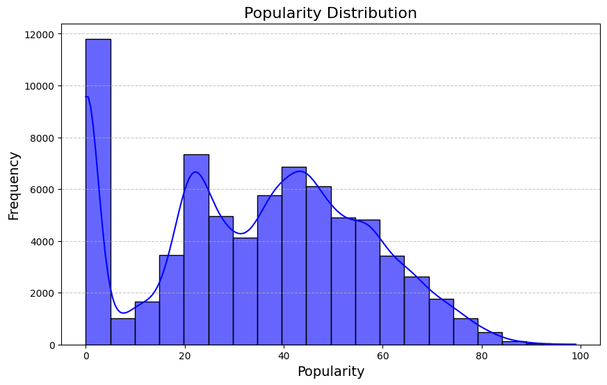

```python
import matplotlib.pyplot as plt
import seaborn as sns

plt.figure(figsize=(10, 6))
sns.histplot(data['popularity'], bins=20, kde=True, color='blue', alpha=0.6)
plt.title('Popularity Distribution', fontsize=16)
plt.xlabel('Popularity', fontsize=14)
plt.ylabel('Frequency', fontsize=14)
plt.grid(axis='y', linestyle='--', alpha=0.7)
plt.show()
```

The Popularity Distribution histogram shows the distribution of track popularity scores in the dataset. Most tracks have popularity clustered around the lower end (0-40), while fewer tracks achieve high popularity scores (80+). This insight reveals that only a select few tracks dominate in popularity, which is typical for datasets involving user preferences.

**Danceability, Energy, and Valence Correlation**

> Scatter plots to analyze how features like danceability, energy, and valence correlate with popularity, overlaying them with regression lines.

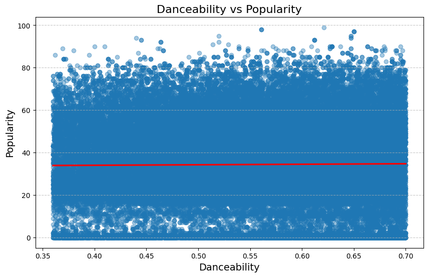

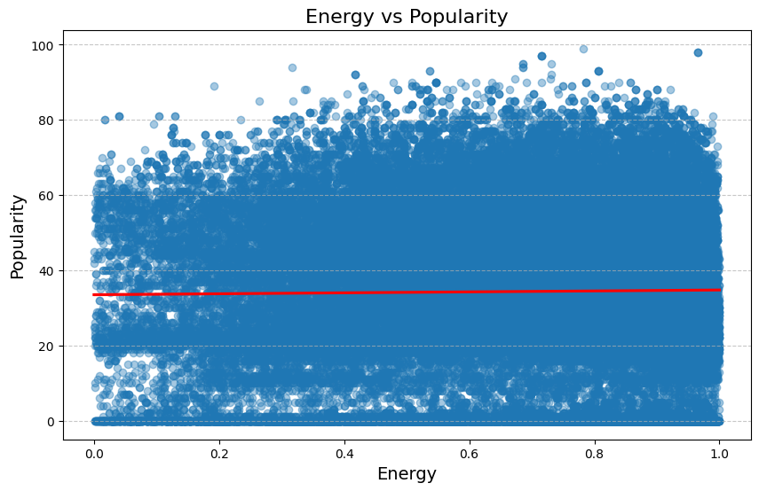

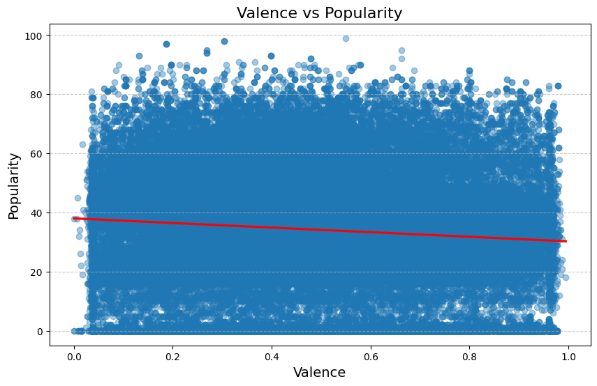

```python
features_to_plot = ['danceability', 'energy', 'valence']

for feature in features_to_plot:
    plt.figure(figsize=(10, 6))
    sns.regplot(data=data, x=feature, y='popularity', scatter_kws={'alpha': 0.4}, line_kws={'color': 'red'})
    plt.title(f'{feature.capitalize()} vs Popularity', fontsize=16)
    plt.xlabel(feature.capitalize(), fontsize=14)
    plt.ylabel('Popularity', fontsize=14)
    plt.grid(axis='y', linestyle='--', alpha=0.7)
    plt.show()
```

**Popularity and Genre Analysis**

> Analyze the average popularity of tracks across genres.

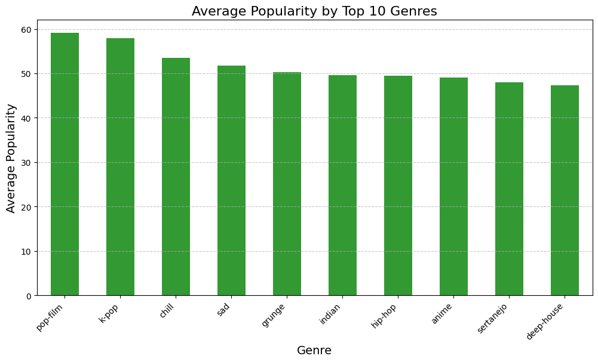

```python
top_genres = data.groupby('track_genre')['popularity'].mean().sort_values(ascending=False).head(10)

plt.figure(figsize=(12, 6))
top_genres.plot(kind='bar', color='green', alpha=0.8)
plt.title('Average Popularity by Top 10 Genres', fontsize=16)
plt.xlabel('Genre', fontsize=14)
plt.ylabel('Average Popularity', fontsize=14)
plt.xticks(rotation=45, ha='right')
plt.grid(axis='y', linestyle='--', alpha=0.7)
plt.show()
```

This bar chart displays the average popularity of tracks across the top 10 genres. It highlights which genres are generally more popular. Genres at the top suggest that their tracks resonate well with listeners, making this a valuable insight for music producers or platforms. Pop film and KPop are the most popular genres.

**Explicit vs. Non-explicit Tracks**

> Compare the popularity of explicit vs. non-explicit tracks using a bar chart.

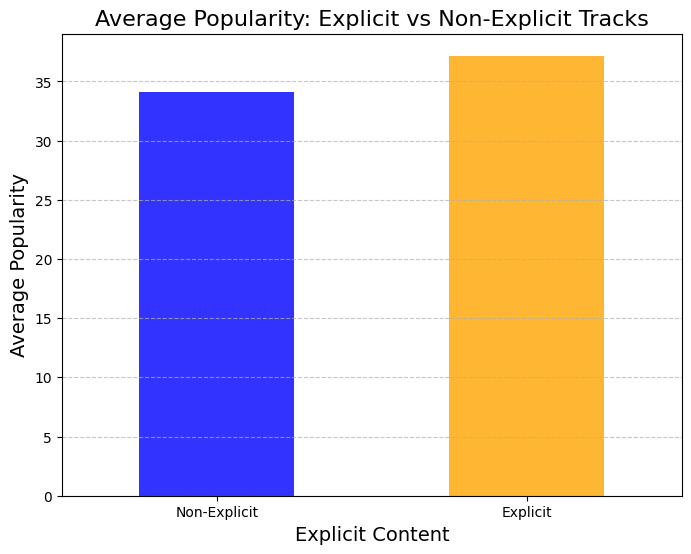

```python
explicit_popularity = data.groupby('explicit')['popularity'].mean()

plt.figure(figsize=(8, 6))
explicit_popularity.plot(kind='bar', color=['blue', 'orange'], alpha=0.8)
plt.title('Average Popularity: Explicit vs Non-Explicit Tracks', fontsize=16)
plt.xlabel('Explicit Content', fontsize=14)
plt.ylabel('Average Popularity', fontsize=14)
plt.xticks(ticks=[0, 1], labels=['Non-Explicit', 'Explicit'], rotation=0)
plt.grid(axis='y', linestyle='--', alpha=0.7)
plt.show()
```

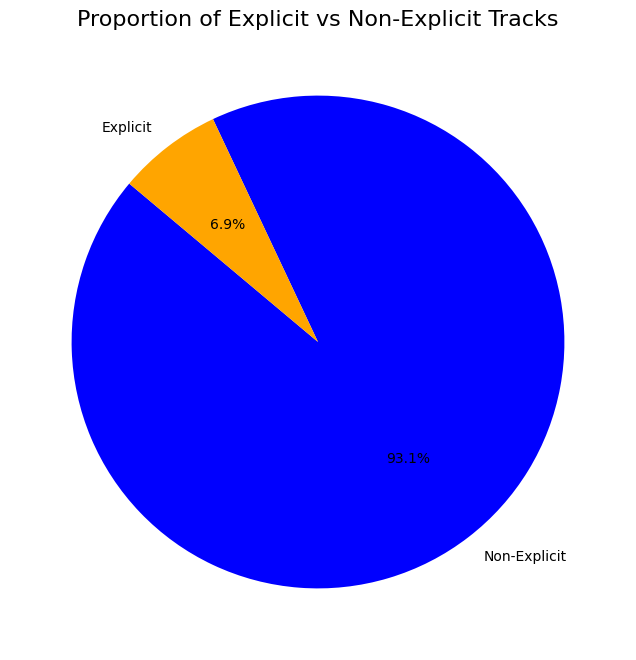

```python
# Creating a new pie chart: Explicit vs. Non-Explicit Tracks as proportions

# Calculate proportions
explicit_counts = data['explicit'].value_counts()

# Create a pie chart
plt.figure(figsize=(8, 8))
explicit_counts.plot(kind='pie', autopct='%1.1f%%', startangle=140, labels=['Non-Explicit', 'Explicit'], colors=['blue', 'orange'])
plt.title('Proportion of Explicit vs Non-Explicit Tracks', fontsize=16)
plt.ylabel('')  # Remove y-label for a cleaner look
plt.show()
```

This is interesting because while explicit tracks are more popular there are far less of them.

**Correlation Between Relationships**

> A correlation heatmap to explore relationships between all numerical features, providing insights into how different attributes influence each other.

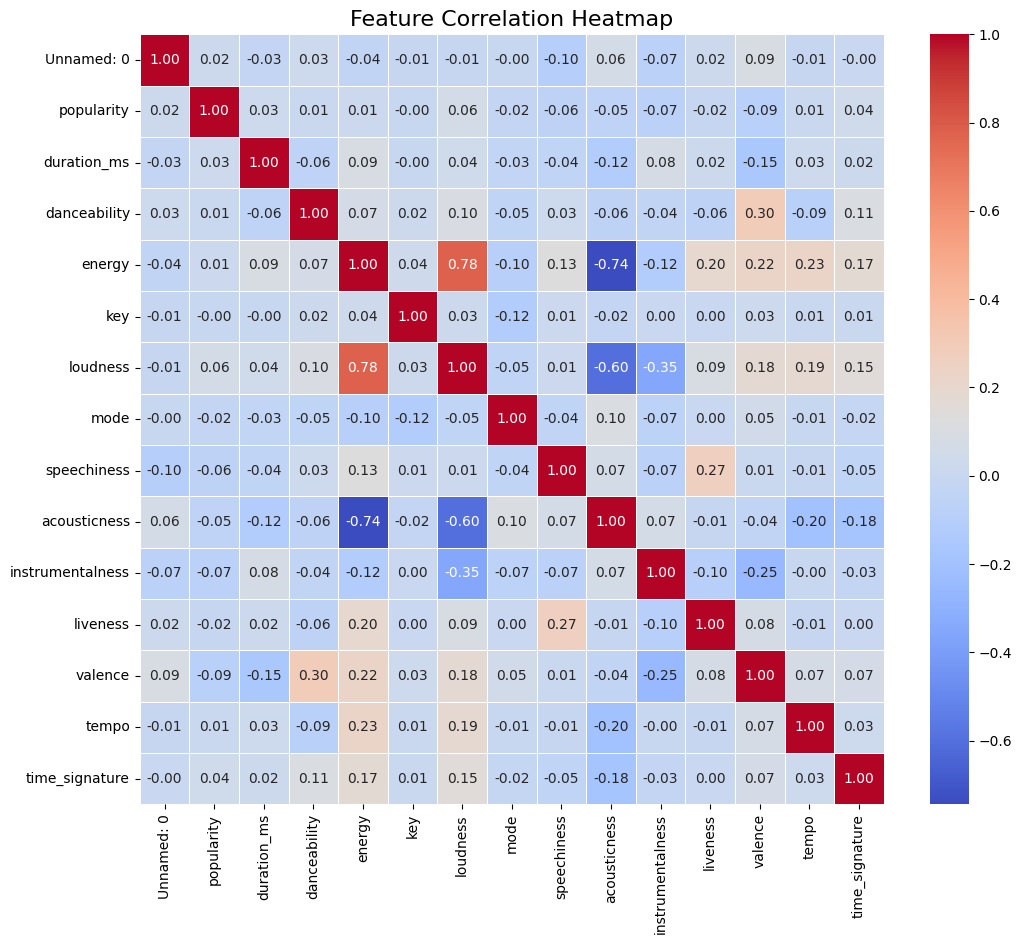

```python
numeric_columns = data.select_dtypes(include=['float64', 'int64'])

plt.figure(figsize=(12, 10))
correlation_matrix = numeric_columns.corr()
sns.heatmap(correlation_matrix, annot=True, cmap='coolwarm', fmt='.2f', linewidths=0.5)
plt.title('Feature Correlation Heatmap', fontsize=16)
plt.show()
```

# **Insights and Conclusion**

### **Overall Analysis and Insights**

This analysis provides a comprehensive look into the dataset, focusing on the factors influencing track popularity, audience preferences, and content trends. The findings reveal significant trends in how certain audio features, genres, and track characteristics contribute to a track's success. This helps provide insight into strategies for creating popular tracks. This can be used by producers and different streaming platforms (not only Spotify)to create better strategies to make tracks more successful and connect with listeners.

#### **Popularity Trends**

The majority of tracks in the dataset have low popularity, with only a few achieving high scores. This skewed distribution reflects a power-law dynamic in music consumption, where a minority of tracks dominate listener attention.This insight underscores the importance of identifying the attributes of highly popular tracks to replicate their success. For new and emerging artists, this dynamic creates a challenge for them to gain visibility and break into this competitive market. A way this dynamic can be changed is by having streaming platforms recommend lesser known tracks/artists in similar listening genres to help diversify listener attention. Streaming platforms can understand this imbalance to make changes and upgrades to their recommendation algorithms.

#### **Genre Analysis**

Genre plays a pivotal role in popularity. The analysis shows that a few dominant genres consistently outperform others in average popularity, pointing to their mass appeal. This finding suggests that focusing on these genres could yield higher engagement and revenue. However, it also presents an opportunity to explore underrepresented genres for niche markets. Streaming platforms can leverage this knowledge by recommending niche genres to users with specific tastes and interests in similar genres. By introducing users to new (potentially interesting) genres, platforms can help users broaden their interests. This will not only help make the user experience better but it will help build loyalty by showing the users the benefits the platform brings.

#### **Correlation Patterns**

The correlation heatmap revealed strong interconnections between features. For example, energy and loudness are highly correlated, emphasizing that energetic tracks often have higher loudness levels. Such insights provide actionable guidance for both music production and recommendation algorithms, ensuring tracks are fine-tuned to match listener preferences. Platforms can use this insights to improve recommendation algorithm. By understanding these correlations the platforms can help refine suggestions by grouping tracks with similar feature profiles. For example, recommending tracks with high energy and loudness to users who enjoy energetic playlists can improve user experience.

### **Conclusion**

This analysis offers actionable insights into the dynamics of music popularity. By identifying the attributes that contribute to a track's success and understanding the audience's preferences, stakeholders across production, marketing, and streaming can make data-driven decisions to maximize impact and revenue. By looking at key findings such as the importance of danceability, energy, as well as the role of genres and explicit content, helps provide a roadmap for crafting music that aligns with listener expectations while also finding places for innovation in underrepresented areas. This helps music artsists and producers to find and create music that can appeal to the most people. Future research could delve deeper into temporal trends and evolving genre preferences to predict shifts in listener behavior. Analyzing regional differences and their impact on genre preferences can help stakeholders adapt to global and local markets.